# Applying Markovian Models to Quantify Bimolecular Simulations:

Investigating the Ligand Binding Dynamics and Encounter Complex Structure of Dihydrofolate Reductase using Molecular Dynamic Simulations

Daniel Groom

Below proceeds the methods, outlined within “Methods 2.2 – Analysis using R” within the main text, that were used within this project for the investigation into the dynamics of Basins of Attraction on the surface of DHFR.

## 2.2.1 - Defining Basins of Attraction

Regions of high ligand spatial density were resolved using a 3D Kernel Density Estimate consistent with Methods 2.2.1. and have been plotted against the protein backbone as shown within Figure 3.3.A

```r
limnu<- 35
slim<-c(-limnu,limnu)
boxlim<-c(slim,slim,slim)
lev<-Trj3D$d*1000
levv <- 0.15
#xyz - Calpha coordinates of the protein backbone
KDE <- lines3d(xyz[,1],xyz[,2],xyz[,3],col="black", xlim=rg,ylim=rg,zlim=rg,phi =30,theta =30, box=T, lit=F)+
  contour3d(lev,level=levv,Trj3D$x,Trj3D$y,Trj3D$z, color= "#08306b", color2= "white", add=T, engine="rgl", lit=T)+
  axes3d(edges = "bbox", labels = TRUE, tick = TRUE, nticks = 5, box = FALSE, expand = 1.5, xlab="x",ylab="y",zlab="z")+
  view3d(userMatrix = newv)
rglwidget(elementId = "KDE")
```

[interactive chart not shown]

These regions were then resolved as individual points, referred to in the text as “Cluster-points”, which were used to define discrete Basins of Attraction using a k-means clustering analysis as shown within Figure 3.3.B. within the main text.

[interactive chart not shown]

Principal Coordinate Analysis was conducted on the resulting Cluster-points to group Basins of Attraction into Diffusive Binding Sites due to their spatial relation with one another. Figure 3.3.C was constructed using the below code.

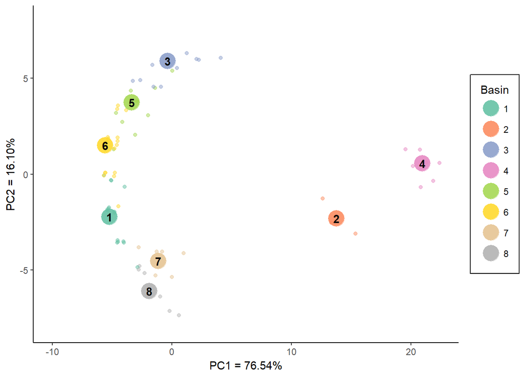

```r
clustercom2 <- cbind(clustercom)
colnames(clustercom2) <- c("dim1","dim2","dim3","Cluster")
###append for accurate labels
Clushubb <- cbind(clushub,Cluster=1:nclus)
Cluscom_w_hub <- rbind(Clushubb, clustercom2)
#pairwise distances
dis_cluscom_w_HUB<- cdist(Cluscom_w_hub[1:3],Cluscom_w_hub[1:3])
#the analysis
PC_CwH1 <- prcomp(dis_cluscom_w_HUB,center = TRUE,scale. = TRUE)



#extract x/y for ggplot
PCi_CwH <- data.frame(PC_CwH1$x, Cluster=Cluscom_w_hub$Cluster)
#save(PCi_CwH, file="PCi_wH Rigid Vac.RData")
#or alt. use autoplot, limited aes commands


###PCoA Plot
###Plot Topographic  - Figure 3.3C
dtmp <- dim(PCi_CwH)[1]
plot2 <- ggplot(PCi_CwH[(nclus+1):dtmp,],aes(x=PC1,y=PC2, col=factor(Cluster)), show.legend=FALSE)+
  geom_point(alpha=0.5, show.legend=FALSE)+
  theme_classic()+
  labs(colour="Cluster")+
  scale_colour_brewer(palette = "Set2", direction = 1)+
  theme(legend.box.background = element_rect(),legend.box.margin = margin(4, 4, 4, 4))+
  geom_point(data=PCi_CwH[1:nclus,],aes(x=PC1,y=PC2, col=factor(Cluster)), size=7,alpha= 0.9, show.legend=T)+
  geom_text(data=PCi_CwH[1:nclus,],aes(label=Cluster, fontface= "bold"), col= "grey 3", show.legend = FALSE)+
  expand_limits(x=c(-10,15), y=c(-8,8)) + xlab("PC1 = 76.54%") + ylab("PC2 = 16.10%")+ labs(colour="Basin")
plot2
```

## 2.2.2 - Mapping trajectories into basins of attraction

Once basins were assigned to the Cluster-points, Trajectory frames could then be compared and assigned to their nearest basin. This in turn produced trajectory runs appended with the basins they migrate too and allowed for the sampling of mobile trajectories that migrated between multiple basins.

```r
###Assigning Trajectories to Basins - Thanks to Tinsley (2018) for his work


#remove trajectories that dont go near any cluster points - this can be done in previous loop
names(clustnumb) <- seq_along(clustnumb)
clustnumb[sapply(clustnumb, is.null)] <- NULL

#assigns the trajectory points close to a cluster point to that clusters number
clustercom[,4] <- as.numeric(clustercom[,4])
for (i in 1:length(clustnumb)) {
  clustpoint2 <- NULL
  clustpoint <- clustercom[rownames(clustercom) %in% clustnumb[[i]][,1],]
  for (y in 1:nrow(clustnumb[[i]])){
    c <- clustnumb[[i]][y,]
    c2 <- which(rownames(clustpoint) == c)
    clustpoint2 <- (rbind(clustpoint2, clustpoint$`kcluster$cluster`[c2]))
  }
  clustnumb[[i]] <- cbind(clustnumb[[i]], clustpoint2)
}

#make cluster numer a factor
for (p in 1:length(clustnumb)) {
  clustnumb[[p]][,2] <- factor(clustnumb[[p]][,2])
}

###LOOKS FOR MULT_CLUSTERS
mult_cluster <- NULL
for (b in 1:length(clustnumb)){
  factornumb <- table(clustnumb[[b]][,2])
  if (nrow(factornumb) >= 2) { #### a=nclus
    mult_cluster <- c(mult_cluster, b)
    mult_cluster2 <- NULL
    clustnumbnames <- names(clustnumb)
  }
}
for (c in 1:length(mult_cluster)) {
  mult_cluster2 <- c(mult_cluster2, clustnumbnames[mult_cluster[c]])
  tmpsub <- clustnumb[mult_cluster2]
}
```

## 2.2.3 - Constructing a Network for migration during Diffusive Binding

```r
###CONSTRUCT NETWORK - GOLDEN EGG PATCH - Groom (2018)
tempnet <- NULL
output<- NULL
##SAMPLE MULTICLUSTERS FOR RELATIONAL INFO/EDGE/PROP - Methods 2.2.3
for (d in clustnumbnames) {
  tmpsubb <- clustnumb[[d]][["clustpoint2"]]
  rletmp <- rle(as.numeric(levels(tmpsubb)[as.integer(tmpsubb)]))
  ###This is a list of the basins for each traj.
  hubnet<- rletmp$values
  ###This is the length of runs
  hubkin <- rletmp$lengths
  ##Looks at how long the run is, uses that to make sure a traj. is all accounted for
  ln <- dim(as.data.frame(hubnet))[1]
  tempd2 <- NULL
  d2pr <-NULL
  for (e in 1:ln) {
    ###check to see if e = penultimate migration, if it's the final one e+1 in else failes/no further migration
    if ((e+1 > ln)==TRUE) {
      warningg <- paste(d,"has been processed, calculating probability", sep=" ")
    }
    #takes the basin in the rle output, identifies adjacent basin, records the length of time spent within the original basin
    else {
      tempnet <-data.frame(hubnet[e], hubnet[e+1],hubkin[e])
      colnames(tempnet) <- c("N1","N2","Time")
      d2pr <- rbind(d2pr, tempnet)
    }
  }
  for (z in 1:nclus){
    if (any(d2pr$N1 == z)==FALSE){
    }
    ###Early adaptations involved simply appending on each trajectory to a master file, rbind ran into issues with RAM; aggregation serves as a compression method
    else {
      subset1<- d2pr[which(d2pr$N1==z),,]
      aggr <- aggregate(subset1, by=list(subset1$N2), FUN=sum)
      aggr2 <- as.data.frame(cbind(z,aggr$Group.1,(aggr$N1/z),aggr$Time))
      colnames(aggr2) <- c("N1","N2","nmigrate","Time")
      output <- rbind(output, as.data.frame(aggr2))
      colnames(output) <- c("N1","N2","nmigrate","Time")
    }
  }
}
###Initial Output is all of the aggr2's which is then reaggregated to give an accurate prop of the whole population



###reaggregates the output results in a final graph
W_edgelist <- NULL
for (i in 1:nclus){
  subset2<- output[which(output$N1==i),,]
  aggrout <- aggregate(subset2, by=list(subset2$N2), FUN=sum)
  ##calc prob of retention
  mrkout <- 1-(sum(aggrout$nmigrate)/sum(aggrout$Time))
  mrkpout <- as.vector(c(i,i,mrkout))
  #calc prob of leaving
  pbout <- aggrout$nmigrate/sum(aggrout$Time)
  elout <- cbind(i,aggrout$Group.1,pbout)
  elout <- rbind(elout,as.numeric(mrkpout))
  W_edgelist<- rbind(W_edgelist,elout)
}


## Give them names
colnames(W_edgelist) <- c("N1","N2","Probability")
```

Above outlines Methods 2.2.3. A network was produced to quantify diffusive binding and basin dynamics, dependent on the rle() function. The code above has been commented describing each step.

Below shows part of the the Weighted Edge List output, where each row indicates a directional edge between basins starting at N1 and ending at N2 as well as the probability of that edge occuring.

```r
head(W_edgelist)
```

```
##      N1 N2  Probability
## [1,]  1  3 0.0001612197
## [2,]  1  5 0.0022570764
## [3,]  1  6 0.2078583109
## [4,]  1  7 0.0007370045
## [5,]  1  8 0.0048365923
## [6,]  1  1 0.7841497962
```

Below shows the method for simplifying the resulting network outlined within Figure 3.4.A-B using igraph. However this can also be plotted against the protein backbone as seen within Figure 4.1.C and below.

```r
##For Figure 3.4 - simplify values with a prob of >=0.005
wammend2 <- as.data.frame(W_edgelist[W_edgelist[,3]>=0.005,,drop=F])
wammend2$Probability <- specify_decimal(wammend2$Probability,3)

###Convert into igraph object
net<- graph_from_data_frame(wammend2)

#PREP COLOURS
colr <- wammend2$N1
colr<- get_colors(colr, group.col = brewer.pal(nclus, "Set2"))
```

[interactive chart not shown]

## 2.2.4 - Calculating the Inter-Basin Transition Matrix

Once the weighted edge list was constructed, a non-binary Transition Matrix for the resulting graph was produced where values equalled the probability of migrating from one basin to another between frames. The resulting matrix represented a MSM model and was analysed using the markovchain package.

```r
net2 <- graph_from_data_frame(W_edgelist)
ma_transitionProbs <- prop.table(as.matrix(get.adjacency(net2, attr="Probability")),1)
W_adjacency<-as.matrix(get.adjacency(net2, attr="Probability"))
#write.csv(W_adjacency, file="Transition Matrix.csv")


tmA <- ma_transitionProbs
netmark <- new("markovchain",transitionMatrix= tmA ,
               name="RigidVacMarkov")
netmm <- netmark[,][,]
```

Once this initial processing was done and the Transition Matrix produced, Steady State analysis outlined within Figure 3.6 could be conducted.

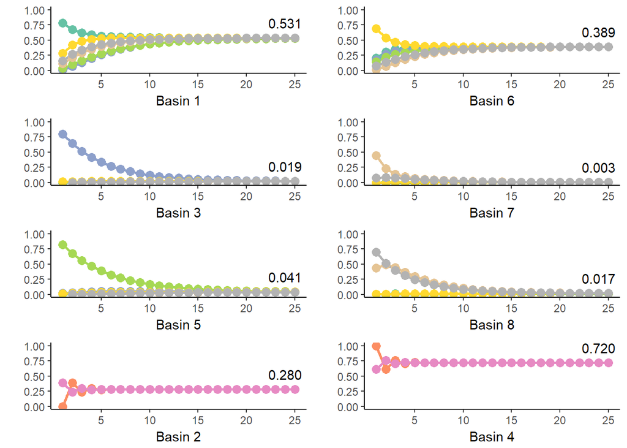

```r
###STEADY STATE GRAPHS
arrayLop <- NULL
arwahay<-NULL
###genn= generation number, the max raised 'n'
genn <- 25

##makes an array where each layer is the powered transition matrix
for (i in 1:genn){
  loopnam <- paste("T",i,sep="")
  nmloop <- netmark^i
  arrayLop <- cbind(arrayLop, as.matrix(nmloop[,][,]))
}
###The produced array is the 2D matrix with each 3D layer representing successive power n=1,2,3..,25
arwahay <- array(data=arrayLop, dim = c( nclus , nclus , genn ))
```

## 2.2.5 - Network Analysis

The simplified network produced from methods outlined above within 2.2.3 was then analysed using a Graph Theory approach. Below shows the code applied to produce Figure 3.5. to gain an insight into the simplified network toplogy.

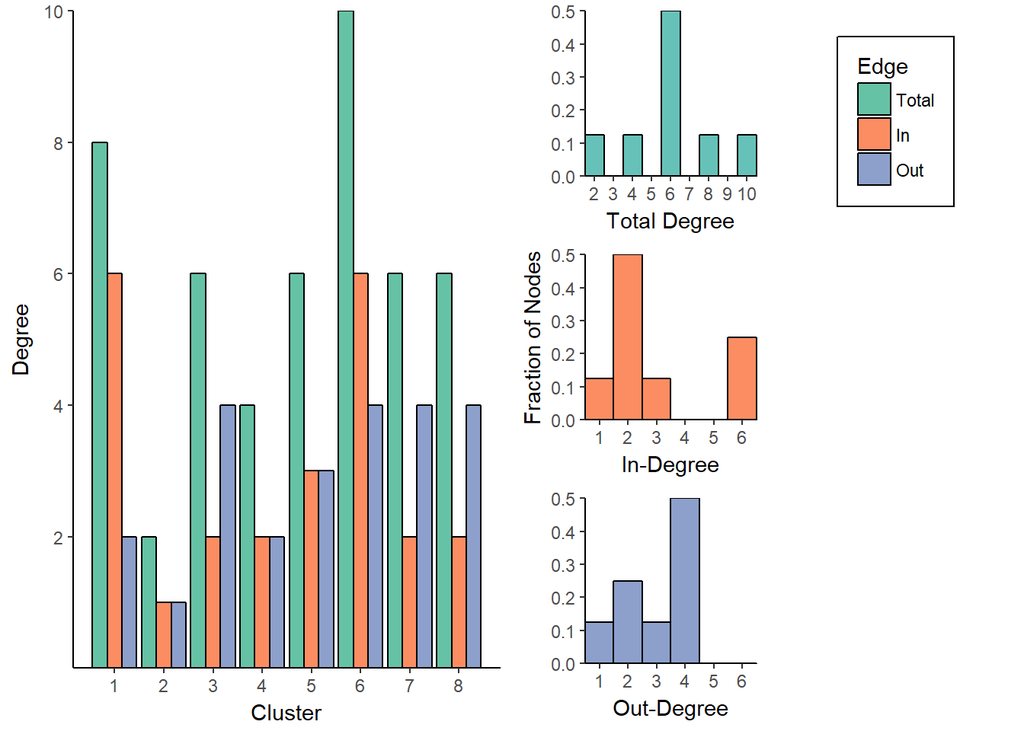

```r
out<-NULL
inn<-NULL
##Initally the In-/Out-Degrees are isolated
for (i in 1:nclus){
  a <-wammend2[wammend2$N1==i,,drop=F]
  out <- rbind(out,a)
  b <-wammend2[wammend2$N2==i,,drop=F]
  inn <- rbind(inn,b)
}

###Nice names
invout<-cbind(as.data.frame(table(t(out$N1))), as.data.frame(table(t(inn$N2)))$Freq, graph.strength(net))
colnames(invout)<- c("Cluster","Out","In","Total")
invout<-cbind(invout$Cluster,invout$Total,invout$In, invout$Out)
colnames(invout)<- c("Cluster","Total","In","Out")
invout<- as.data.frame(invout)
m.invout<- melt(invout, id.vars='Cluster')
colnames(m.invout)<- c("Cluster", "Edge", "value")

##Subset Directional
for (i in c("Total","In","Out")){
  loopnam <- paste("Subset",i,sep="")
  p <- subset(m.invout, Edge==i)
  assign(loopnam, p)
}


##PLOT - Figure 3.5A
bar <- ggplot(m.invout, aes(Cluster, value))+
  geom_bar(aes(fill = Edge), position = "dodge", stat="identity", color="black")+
  theme_classic()+
  scale_fill_brewer(palette = "Set2", direction = 1)+
  theme(legend.box.background = element_rect(),legend.box.margin = margin(4, 4, 4, 4))+
  ylab("Degree") + scale_y_continuous(breaks = c(2,4,6,8,10), expand = c(0, 0))+
  scale_x_continuous(breaks = c(1:nclus))+
  guides(color=guide_legend("Edge"))

legend <- g_legend(bar)

##Degrees - Total
p1<-ggplot(SubsetTotal, aes(x=value))+
  geom_histogram(aes(y=..count../sum(..count..)), fill="#66c2b9", color="black", binwidth = 1)+
  theme_classic()+
  scale_fill_brewer(palette = "Set2", direction = 1)+
  ylab("") + scale_y_continuous(expand = c(0, 0))+
  xlab("Total Degree") + scale_x_continuous(breaks = c(0:10), expand = c(0, 0))

##This was then repeated for both subsetted directional degrees to produce Figure 3.5.B
```